# r_sample: analysis of simulated data

Michael D Evans

5/17/2021

# Mindfulness and Risk Appraisal

git repository: https://github.com/evans2md/r_sample  
In this mock-study, we are exploring whether a mindfulness coaching app improves the ability to accurately assess risk and thus make more informed decisions.

Our sample is comprised of 1000 participants, 500 of which used the mindfulness app (treatment condition) and 500 did not (control). To see how the data were generated, see https://www.mdevans.me/projects/r_sample/r_sample_generate.html.

Background: Participants completed a behavioral task that measures risk behavior, the “Icecream Game” (demo: https://mdevans.me/projects/icecream; an adaption of the BART task, Lejuez et al. 2002), followed by completing the Five Factor Mindfulness Questionnaire (FFMQ; Baer et al., 2006), a 39-item survey that assess for five different areas of mindfulness. Here, we are exploring whether there are any significant differences between the treatment and control groups on both performance in the Icecream game, as well as on the FFMQ. If any differences are found, we will use the FFMQ data to see which factors of mindfulness show the greatest improvement from app use, as well as which factors of mindfulness contribute to improvements in behavioral performance. Identifying such information will allow us to make design recommendations on how to improve the app to better maximize behavioral outcomes.

```r
df <- read.csv('ffmq_ic_data_demo.csv') # load in data, file on git or at https://www.mdevans.me/projects/r_sample/ffmq_ic_data_demo.csv
# to see how data were generated:
set.seed(42) # fix random seed for demo purposes
```

Now that we have the data, lets check our sample demographics to see if there are any gender or age differences between our groups.

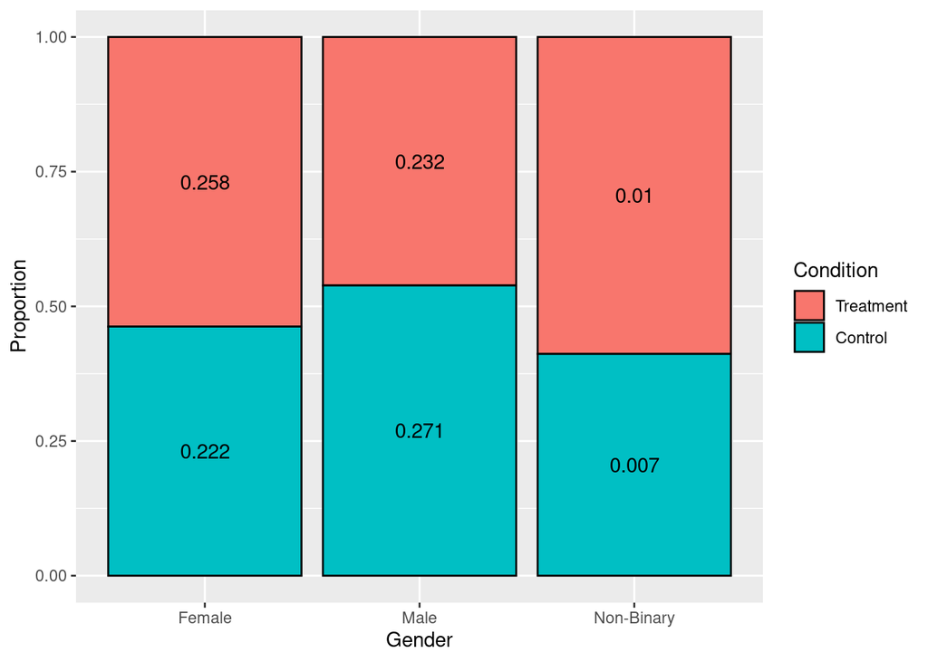

```r
# gender proportions
plt<-ggplot(aes(x=gender,fill=as.factor(group)),data=df)+
  geom_bar(color='black',position='fill')+
  geom_text(stat='count', aes(label=(..count..)/sum(..count..)), position = position_fill(0.5))+
  labs(fill='Condition',y='Proportion', x='Gender')+
  scale_fill_discrete(label=c('Treatment','Control'))+
  scale_x_discrete(labels=c('f'='Female','m'='Male','nb'='Non-Binary'))
print(plt)
```

```r
plt<-ggplot(data=df,aes(x=group,fill=gender))+
  geom_bar(color='black')+
  geom_text(stat='count', aes(label=..count..),position = position_stack(0.5))+
  labs(x='Condition',y='Count',fill='Gender')+
  scale_fill_discrete(labels=c('f'='Female','m'='Male','nb'='Non-Binary'))
  xlim('Treatment','Control') # set x-labels
```

[output not shown]

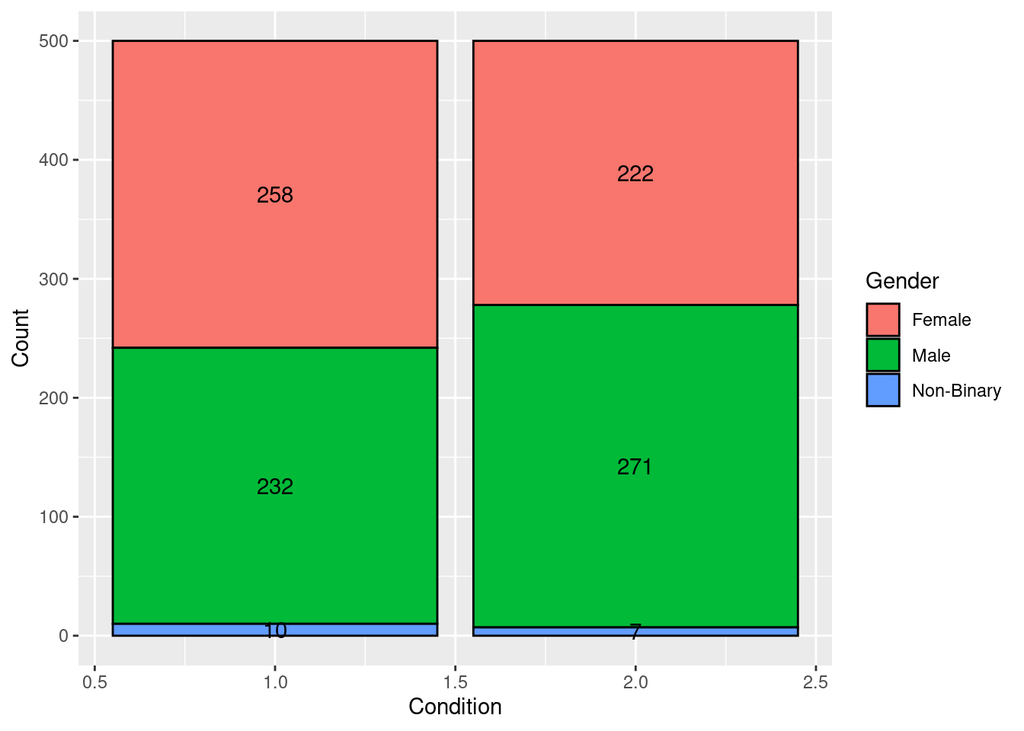

```r
print(plt)
```

```r
## chi-square to see if genders equally distributed
gender.x2 <- chisq.test(x=df$gender,y=df$group)
print(gender.x2)
```

```
##
##  Pearson's Chi-squared test
##
## data:  df$gender and df$group
## X-squared = 6.2533, df = 2, p-value = 0.04387
```

```r
print(gender.x2$residuals)
```

```
##          df$group
## df$gender          1          2
##        f   1.1618950 -1.1618950
##        m  -1.2296050  1.2296050
##        nb  0.5144958 -0.5144958
```

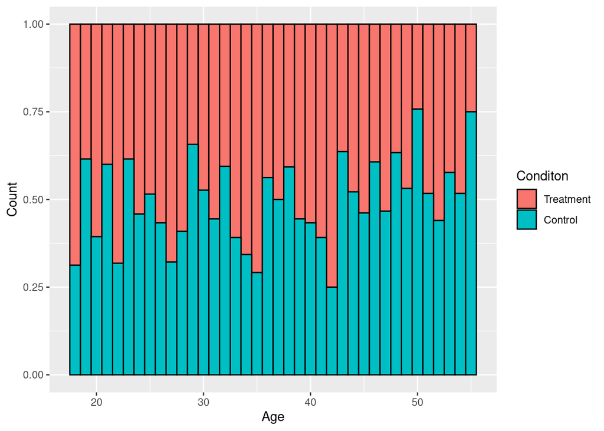

```r
# age
plt <- ggplot(df, aes(x=age,fill=as.factor(group))) +
  geom_histogram(binwidth = 1,color='black',position = 'fill')+
  labs(fill='Conditon',x='Age',y='Count')+
  scale_fill_discrete(label=c('Treatment','Control'))
print(plt)
```

```r
print(t.test(df[df$group == 1,]$age,df[df$group == 2,]$age))
```

```
##
##  Welch Two Sample t-test
##
## data:  df[df$group == 1, ]$age and df[df$group == 2, ]$age
## t = -2.1181, df = 996.35, p-value = 0.03441
## alternative hypothesis: true difference in means is not equal to 0
## 95 percent confidence interval:
##  -2.7710144 -0.1057798
## sample estimates:
## mean of x mean of y
##  35.67452  37.11292
```

```r
# since not normally distributed, confirm w non-parametric
print(wilcox.test(df[df$group == 1,]$age,df[df$group == 2,]$age))
```

```
##
##  Wilcoxon rank sum test with continuity correction
##
## data:  df[df$group == 1, ]$age and df[df$group == 2, ]$age
## W = 115591, p-value = 0.03937
## alternative hypothesis: true location shift is not equal to 0
```

In the current sample, there IS a significant difference in group gender demographics, most strongly in the number of self identified males (under-sampled in tx group), followed up by females (over-sampled in tx group), and least by those who identify as non-binary/other (though slightly over-sampled in tx group; X^2(2, N = 1000) = 6.253, p = 0.044)

We also see a significant difference in age (tx mean= 35.67, control mean = 37.11; t(996)=-2.12, p = 0.03). Since we see some demographic differences between groups, it will be important to make sure that any observed effects are generalizable to different demographic groups (as opposed to an effect being driven by older male men, for example).

Next, let’s see if the group that used the mindfulness coaching app demonstrate higher mindfulness scores compared to those who did not, as assessed by the FFMQ.

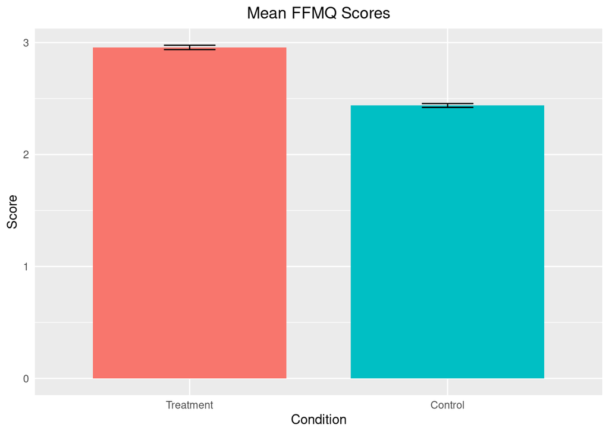

```r
ffmq <- df %>% # pulling out ffmq data
  select(starts_with('ffmq.')) # get columns starting with ffmq

df$ffmq_mean <- to_vec(for(i in 1:nrow(ffmq)) rowMeans(ffmq[i,])) # get mean ffmq for each participant (e.g. row)
df$ffmq_sd <- to_vec(for(i in 1:nrow(ffmq)) sd(ffmq[i,])) # and sd

df_ <- df%>% # for plotting, we'll get the mean of means for each group
  group_by(group) %>%
  summarize(mean = mean(ffmq_mean),
            sd = sd(ffmq_mean),
            count = length(ffmq_mean))

plt <- ggplot(df_, aes(x=group, y=mean, fill=as.factor(group)))+ # plot means
  geom_bar(stat='identity', width = 0.75)+ # as bar plots
  geom_errorbar(aes(ymin=mean-(sd/(sqrt(count))), ymax=mean+(sd/sqrt(count))), width=0.2)+ #sd error bars
  theme(legend.position = "none", # no need for legend (x-labels suffice)
        axis.ticks = element_blank(), # remove ticks
        plot.title = element_text(hjust = 0.5))+ # center title
  xlim("Treatment","Control")+ # set x-labels
  xlab('Condition')+
  ylab('Score')+
  ggtitle('Mean FFMQ Scores')

print(plt)
```

```r
# t test
print(t.test(df[df$group == 1,]$ffmq_mean,df[df$group == 2,]$ffmq_mean)) # quick two-samples t-test comparing means
```

```
##
##  Welch Two Sample t-test
##
## data:  df[df$group == 1, ]$ffmq_mean and df[df$group == 2, ]$ffmq_mean
## t = 19.946, df = 983.38, p-value < 2.2e-16
## alternative hypothesis: true difference in means is not equal to 0
## 95 percent confidence interval:
##  0.4675908 0.5696400
## sample estimates:
## mean of x mean of y
##  2.956872  2.438256
```

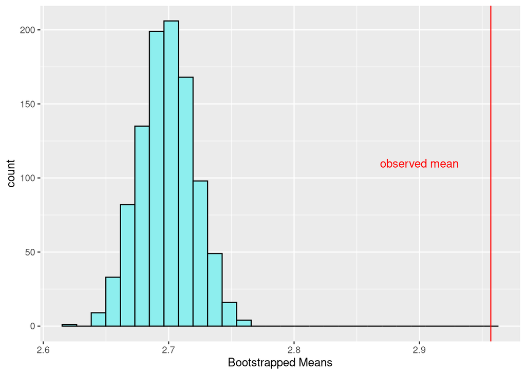

```r
# let's also check whether this is a random effect or not using a bootstrap method to create a null distribution
actual_mean = mean(df[df$group == 1,]$ffmq_mean) # get actual (accurate group id) mean
bs_means = vector() # create empty vector to store bootstrapped sample means
for (i in 1:1e3){ # iterate for the number of desired bootstrapped samples (more is better, 1000 is ok for our purposes)
  bs_sample = mean(sample_n(df,nrow(df[df$group==1,]),replace=TRUE)$ffmq_mean) # sample WITH replacement = sample size
  bs_means <- append(bs_means,bs_sample)
}
plt <- ggplot(data=as.data.frame(bs_means),aes(x=bs_means))+
  geom_histogram(fill='darkslategray2',color='black')+
  geom_vline(xintercept = actual_mean,color='red')+
  annotate('text',x=2.9, y=110, label='observed mean', color='red')+
  labs(x='Bootstrapped Means')
print(plt)
```

```r
print(mean(bs_means>=actual_mean)) # proportion of bootstrapped means below observed i.e. p value
```

```
## [1] 0
```

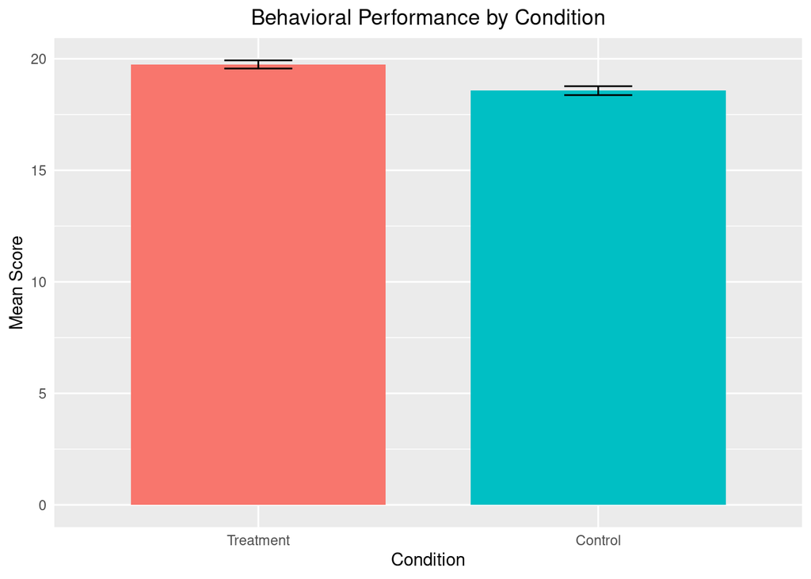

```r
df_ <- df%>% # temporary df
  group_by(group) %>% # grouped by group
  summarize(mean = mean(ic_scoops), # with some basic summary stats; ic_scoops = mean score
            sd = sd(ic_scoops),
            count= length(ic_scoops))

# bar plot of group means + sd error bars
plt <- ggplot(df_, aes(x=group, y=mean, fill=as.factor(group)))+ # plot means
  geom_bar(stat='identity', width = 0.75)+ # as bar plots
  geom_errorbar(aes(ymin=mean-(sd/(sqrt(count))), ymax=mean+(sd/sqrt(count))), width=0.2)+ #se error bars
  theme(legend.position = "none", # no need for legend (x-labels suffice)
        axis.ticks = element_blank(), # remove ticks
        plot.title = element_text(hjust = 0.5))+ # center title
  ylab('Mean Score')+
  xlab('Condition')+
  xlim('Treatment','Control')+ # set x-labels
  ggtitle('Behavioral Performance by Condition')
print(plt)
```

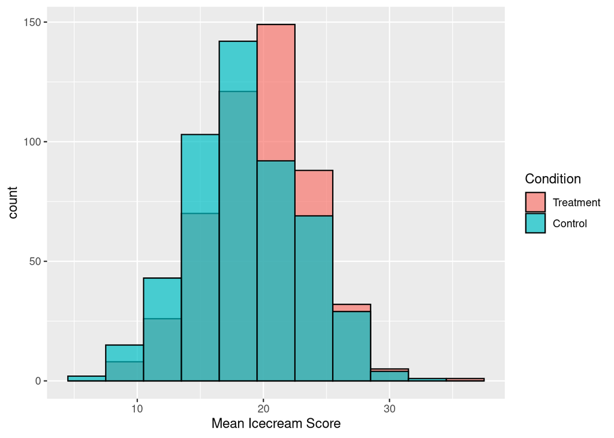

```r
# histogram of group scoop distributions
plt<-ggplot(data=df, aes=(x=ic_scoops))+
  geom_histogram(mapping=aes(x=ic_scoops, fill=as.factor(group)),binwidth=3,color='black', position='identity',alpha=0.7)+
  labs(fill='Condition', x='Mean Icecream Score')+
  scale_fill_discrete(labels=c('Treatment','Control'))
print(plt)
```

```r
# t test
print(t.test(df[df$group == 1,]$ic_scoops,df[df$group == 2,]$ic_scoops))
```

```
##
##  Welch Two Sample t-test
##
## data:  df[df$group == 1, ]$ic_scoops and df[df$group == 2, ]$ic_scoops
## t = 4.3447, df = 990.5, p-value = 1.538e-05
## alternative hypothesis: true difference in means is not equal to 0
## 95 percent confidence interval:
##  0.6446146 1.7065574
## sample estimates:
## mean of x mean of y
##  19.74721  18.57162
```

```r
print(t.test(df[df$group == 1,]$ic_scoops,mu=32))
```

```
##
##  One Sample t-test
##
## data:  df[df$group == 1, ]$ic_scoops
## t = -67.023, df = 499, p-value < 2.2e-16
## alternative hypothesis: true mean is not equal to 32
## 95 percent confidence interval:
##  19.38802 20.10639
## sample estimates:
## mean of x
##  19.74721
```

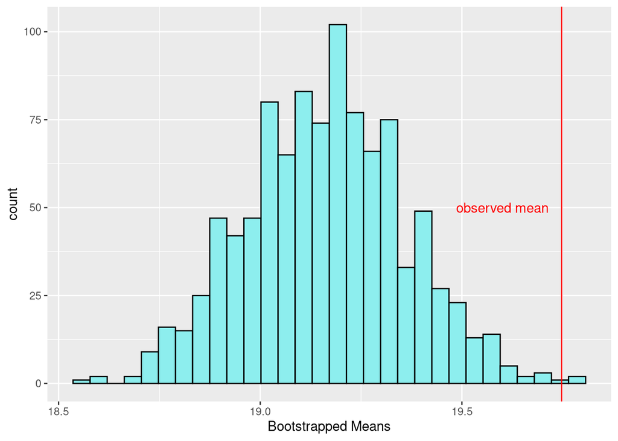

```r
# bootstrap null distribution
actual_mean = mean(df[df$group == 1,]$ic_scoops)
bs_means = vector()
for (i in 1:1e3){
  bs_sample = mean(sample_n(df,nrow(df[df$group==1,]),replace=TRUE)$ic_scoops)
  bs_means <- append(bs_means,bs_sample)
}
plt <- ggplot(data=as.data.frame(bs_means),aes(x=bs_means))+
  geom_histogram(fill='darkslategray2',color='black')+
  geom_vline(xintercept = actual_mean,color='red')+
  annotate('text',x=19.6, y=50, label='observed mean', color='red')+
  labs(x='Bootstrapped Means')
print(plt)
```

```r
print(mean(bs_means>=actual_mean)) # prop. of null dist. below observed mean / p-value
```

```
## [1] 0.002
```

Now that we have evidence that app use is associated with improving the targeted behavior, let’s dig a little deeper to better understand the underlying factors driving this effect. Since we saw we have some differences in gender and age distributions between our two groups, it’s important to see if the overall effect is driven by any particular demographic.

```r
# gender
df_ <- df%>% # temporary df
  group_by(gender,group) %>% # grouped by gender and group
  summarize(mean = mean(ic_scoops), # with some basic summary stats
            sd = sd(ic_scoops),
            count = length(ic_scoops))
print(df_) # display values
```

```
## # A tibble: 6 x 5
## # Groups:   gender [3]
##   gender group  mean    sd count
##   <chr>  <int> <dbl> <dbl> <int>
## 1 f          1  19.7  4.06   258
## 2 f          2  18.8  4.33   222
## 3 m          1  19.8  4.12   232
## 4 m          2  18.4  4.54   271
## 5 nb         1  20.4  4.35    10
## 6 nb         2  18.1  5.92     7
```

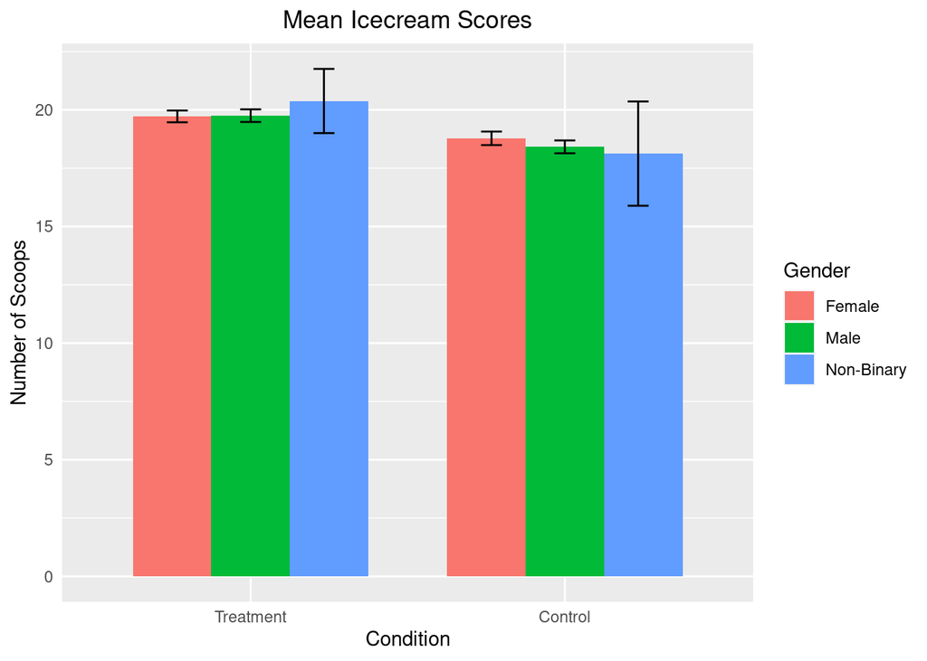

```r
# categorical 2x3 data, bar plot (group x gender)
plt <- ggplot(df_, aes(x=group, y=mean, fill=as.factor(gender)))+ # plot means
  geom_bar(stat='identity', width = 0.75,position='dodge')+ # position targets gender
  geom_errorbar(aes(ymin=mean-(sd/sqrt(count)), ymax=mean+(sd/sqrt(count))), width=0.2, position=position_dodge(.7))+ #sd error bars, position dodge relative to width
  theme(axis.ticks = element_blank(), # remove ticks
        plot.title = element_text(hjust = 0.5))+ # center title
  ylab('Number of Scoops')+
  xlab('Condition')+
  labs(fill='Gender')+
  scale_fill_discrete(labels=c('f'='Female','m'='Male','nb'='Non-Binary'))+
  xlim("Treatment","Control")+ # set x-labels
  ggtitle('Mean Icecream Scores')
print(plt)
```

```r
## run an anova to check for differences
anovaGender = aov(ic_scoops~gender, data=df)
summary(anovaGender)
```

```
##              Df Sum Sq Mean Sq F value Pr(>F)
## gender        2     17    8.67   0.465  0.628
## Residuals   997  18595   18.65
```

```r
TukeyHSD(anovaGender)
```

```
##   Tukey multiple comparisons of means
##     95% family-wise confidence level
##
## Fit: aov(formula = ic_scoops ~ gender, data = df)
##
## $gender
##            diff        lwr       upr     p adj
## m-f  -0.2542202 -0.9010213 0.3925809 0.6261388
## nb-f  0.1660774 -2.3356024 2.6677572 0.9867034
## nb-m  0.4202976 -2.0794250 2.9200203 0.9177455
```

```r
# see very high p values (>0.5)

# follow up w non-parametric to confirm (even though scores appear normally distributed)
kruskal.test(ic_scoops~gender, data=df)
```

```
##
##  Kruskal-Wallis rank sum test
##
## data:  ic_scoops by gender
## Kruskal-Wallis chi-squared = 0.89931, df = 2, p-value = 0.6378
```

```r
# no surprise, we see no significant results
```

From the above analyses, we can say that we do not have any evidence that the observed effect of app use on behavior is driven by any gender-specific effects (F(2,997) = 0.465, p = 0.628). We should note here that our sample only contains a small number of individuals who identified as non-binary, hence the large standard error bars. Next, let’s look at age.

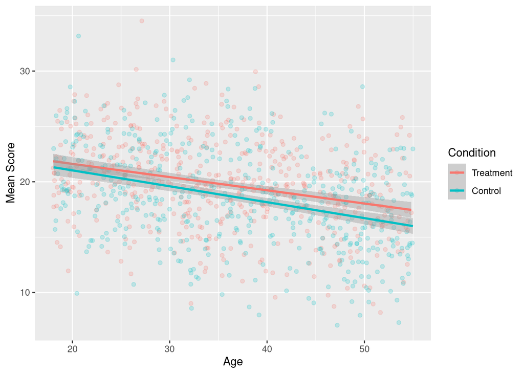

```r
# age
plt <- ggplot(data=df, mapping=aes(x=age,y=ic_scoops, color=as.factor(group)))+
  geom_point(alpha=0.2)+ # plot each individual point
  geom_smooth(method=lm, se=TRUE, fullrange=FALSE, level=0.95)+ # and a regression line 95ci se
  labs(color='Condition',y='Mean Score', x='Age')+ # update labels
  scale_color_discrete(labels=c('Treatment','Control'))
print(plt)
```

```r
# some significance testing of linear model
age.lm <- lm(ic_scoops~age+group, data=df)
summary(age.lm)
```

```
##
## Call:
## lm(formula = ic_scoops ~ age + group, data = df)
##
## Residuals:
##      Min       1Q   Median       3Q      Max
## -11.1927  -2.6371  -0.0681   2.7656  13.6537
##
## Coefficients:
##             Estimate Std. Error t value Pr(>|t|)
## (Intercept) 25.44189    0.57381   44.34  < 2e-16 ***
## age         -0.13200    0.01191  -11.09  < 2e-16 ***
## group       -0.98572    0.25600   -3.85 0.000125 ***
## ---
## Signif. codes:  0 '***' 0.001 '**' 0.01 '*' 0.05 '.' 0.1 ' ' 1
##
## Residual standard error: 4.039 on 997 degrees of freedom
## Multiple R-squared:  0.1263, Adjusted R-squared:  0.1245
## F-statistic: 72.05 on 2 and 997 DF,  p-value: < 2.2e-16
```

Now lets see if how FFMQ scores as associated with performance.

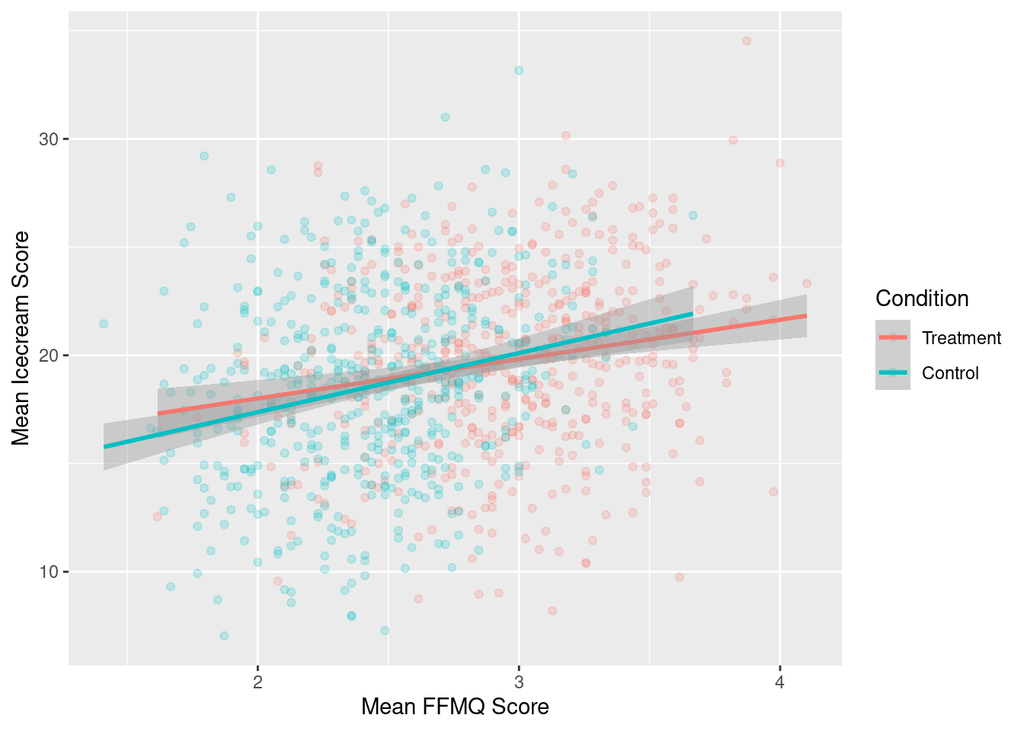

```r
# ffmq x ic_scoops
plt <- ggplot(data=df, mapping=aes(x=ffmq_mean,y=ic_scoops, color=as.factor(group)))+
  geom_point(alpha=0.2)+ # plot each individual point
  geom_smooth(method=lm, se=TRUE, fullrange=FALSE, level=0.95)+ # and a regression line 95ci se
  labs(color='Condition',y='Mean Icecream Score', x='Mean FFMQ Score')+
  scale_color_discrete(labels=c('Treatment','Control'))
print(plt)
```

```r
# significance testing
ffmq.lm <- lm(ic_scoops~ffmq_mean+group, data=df)
ffmq.lm
```

```
##
## Call:
## lm(formula = ic_scoops ~ ffmq_mean + group, data = df)
##
## Coefficients:
## (Intercept)    ffmq_mean        group
##    13.21098      2.21892     -0.02482
```

```r
summary(ffmq.lm)
```

```
##
## Call:
## lm(formula = ic_scoops ~ ffmq_mean + group, data = df)
##
## Residuals:
##      Min       1Q   Median       3Q      Max
## -11.9318  -2.8921   0.0692   2.8360  13.3447
##
## Coefficients:
##             Estimate Std. Error t value Pr(>|t|)
## (Intercept) 13.21098    1.19466  11.058  < 2e-16 ***
## ffmq_mean    2.21892    0.32199   6.891 9.79e-12 ***
## group       -0.02482    0.31279  -0.079    0.937
## ---
## Signif. codes:  0 '***' 0.001 '**' 0.01 '*' 0.05 '.' 0.1 ' ' 1
##
## Residual standard error: 4.182 on 997 degrees of freedom
## Multiple R-squared:  0.06319,    Adjusted R-squared:  0.06131
## F-statistic: 33.62 on 2 and 997 DF,  p-value: 7.401e-15
```

Now that we have found evidence to support our primary hypothesis, that app use will improve risk assessment behavior, let’s see if there are specific aspects of the FFMQ that are most strongly associated with performance in the icecream game. While the FFMQ is designed to be constructed around five-factors, we can look at our data to see if we can recover these factors (that is, if the items associated with each factor are correlated in our sample).

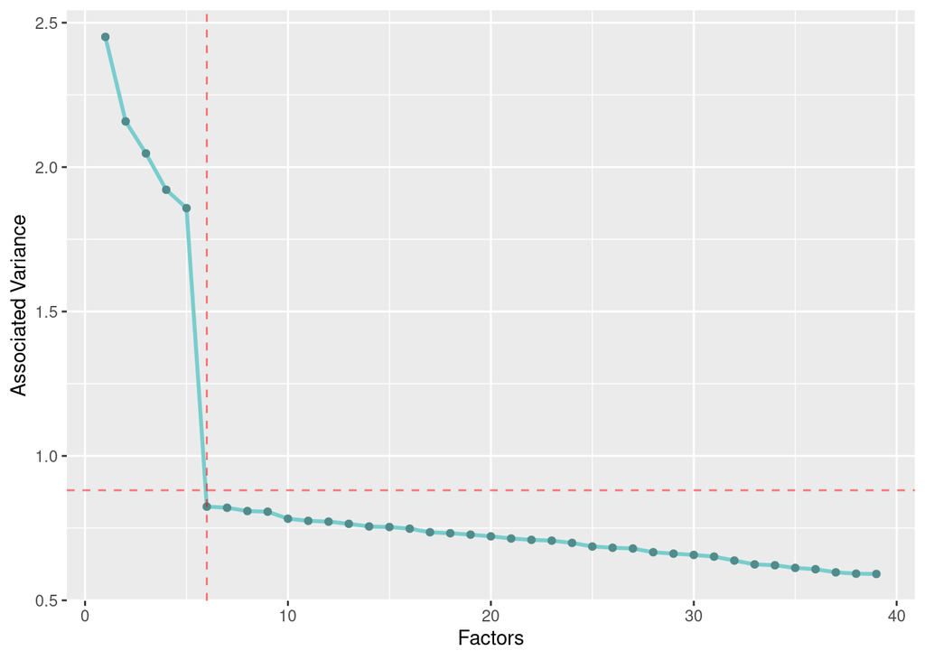

```r
# we can use a principal component factor analysis (uses eigenvalue decomposition)
fit <- princomp(ffmq, cor=TRUE) # gives a vector of n components where n is number of items (in our case, 39), and how much variance accounted for by components
fa_mean = mean(fit$sdev) # get mean variance accounted for by all factors

# plot to look for an "elbow" or drastic drop off in variance accounted for
plt<-ggplot(data=as.data.frame(fit$sdev),aes(x=1:length(fit$sdev),y=fit$sdev))+
  geom_line(color='darkslategray3',size=1)+
  geom_point(color='darkslategray4')+
  geom_hline(yintercept=mean(fit$sdev),color='red',linetype='dashed',alpha=0.5)+
  geom_vline(xintercept = length(fit$sdev[fit$sdev>fa_mean])+1,color='red',linetype='dashed',alpha=0.5)+
  labs(x='Factors',y='Associated Variance')
print(plt) # from our plot, we see a steep drop off in variance accounted for at 5 factors ()
```

```r
n_factors <- length(fit$sdev[fit$sdev>fa_mean]) # we can take the number of factors greater than the mean ***confirm visually
print(paste('suggested number of factors:',n_factors))
```

```
## [1] "suggested number of factors: 5"
```

```r
fa <- factanal(ffmq, factors=n_factors) # cleaner loadings output
fa$loadings
```

```
##
## Loadings:
##          Factor1 Factor2 Factor3 Factor4 Factor5
## ffmq.X1                           0.667
## ffmq.X2   0.722
## ffmq.X3                   0.713
## ffmq.X4                   0.109           0.703
## ffmq.X5           0.706
## ffmq.X6                           0.675
## ffmq.X7   0.724
## ffmq.X8           0.704
## ffmq.X9                                   0.728
## ffmq.X10                  0.695           0.107
## ffmq.X11                          0.673
## ffmq.X12  0.704
## ffmq.X13          0.727
## ffmq.X14                  0.668
## ffmq.X15                          0.681
## ffmq.X16  0.728
## ffmq.X17                  0.695
## ffmq.X18          0.700
## ffmq.X19                                  0.705
## ffmq.X20                          0.690
## ffmq.X21                                  0.720
## ffmq.X22  0.707
## ffmq.X23          0.690
## ffmq.X24                                  0.718
## ffmq.X25                  0.703
## ffmq.X26                          0.690
## ffmq.X27  0.684
## ffmq.X28          0.728
## ffmq.X29                                  0.731
## ffmq.X30                  0.704
## ffmq.X31                          0.679
## ffmq.X32  0.696
## ffmq.X33                                  0.715
## ffmq.X34          0.684
## ffmq.X35                  0.687
## ffmq.X36                          0.663
## ffmq.X37  0.718
## ffmq.X38          0.696
## ffmq.X39                  0.727
##
##                Factor1 Factor2 Factor3 Factor4 Factor5
## SS loadings      4.084   4.042   3.982   3.721   3.678
## Proportion Var   0.105   0.104   0.102   0.095   0.094
## Cumulative Var   0.105   0.208   0.310   0.406   0.500
```

```r
# now that we have our loadings, we can calculate participant scores for each factor and see which factors are most strongly associated w task performance
```

We can also use a correlation plot to see which items are most strongly correlated with one another - clusters of items with strong correlation should map onto the factors we identified using factor analysis.

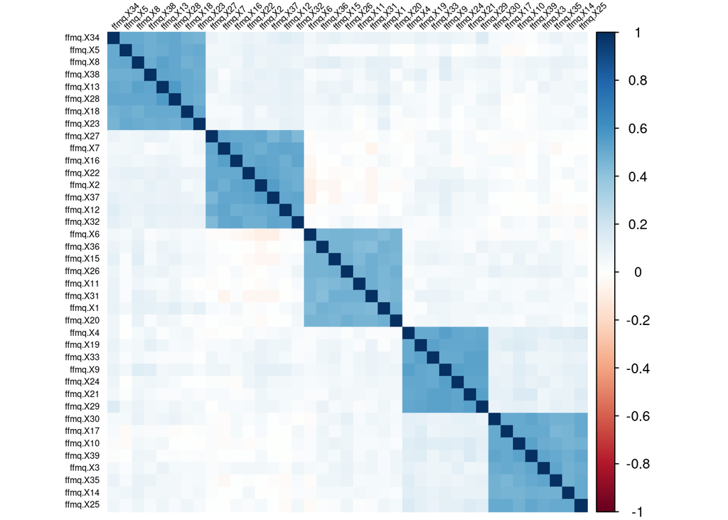

```r
ffmq <- df %>%
  select(starts_with('ffmq.')) # get columns starting with ffmq. (added period because we now have some ffmq_ columns)

ffmq_cor <- cor(ffmq) # create correlation matrix

corrplot(ffmq_cor, method='color', order="hclust",tl.col="black", tl.srt=45,tl.cex = .5) # hclust = hierarchical cluster
```

From our factor analysis, we saw that five factors account for a large proportion of variance within our sample. From the correlational plots, we see five very apparent clusters of highly-correlated items. Not only does this match up with the number of factors we identified, we also see that each cluster contains the expected factor items.

We can look at the actual FFMQ to give them more meaningful labels:  
Factor1 = Describing (e.g. item 27: “Even when I’m feeling terribly upset, I can find a way to put it into words”)  
Factor2 = Awareness (e.g. item 34: “I do tasks automatically without being aware of what I am doing” reverse-scored)  
Factor3 = Non-judging (e.g. item 10: “I tell myself I shouldn’t be feeling the way I’m feeling” reverse-scored)  
Factor4 = Observing (e.g. item 6: “When I take a shower or bath, I stay alert to the sensations of water on my body”)  
Factor5 = Non-reactivity (e.g. item 4: “I perceive my feelings and emotions without having to react to them”)

Next, we should check if there are any group differences in factor scores, how these factors are assocaited with overall FFMQ performance, and how each factor is associated with task performance.

```r
fa_threashold <- 0.5 # set a threshold to have an item belong to a factor
ffmq_ind = 1:length(ffmq) # vector of indicies for ffmq

# get vectors of item indicies
fa1_items = ffmq_ind[fa$loadings[,1]>fa_threashold] # from list of possible indicies, get factor 1 loadings greater than defined threshold
fa2_items = ffmq_ind[fa$loadings[,2]>fa_threashold]
fa3_items = ffmq_ind[fa$loadings[,3]>fa_threashold]
fa4_items = ffmq_ind[fa$loadings[,4]>fa_threashold]
fa5_items = ffmq_ind[fa$loadings[,5]>fa_threashold]

# create a column for each factor mean
df$fa1_mean = rowMeans(ffmq[,fa1_items])
df$fa2_mean = rowMeans(ffmq[,fa2_items])
df$fa3_mean = rowMeans(ffmq[,fa3_items])
df$fa4_mean = rowMeans(ffmq[,fa4_items])
df$fa5_mean = rowMeans(ffmq[,fa5_items])
```

```r
# group differences in factor scores
df_ <- df%>% # for plotting, we'll get the mean of means for each group
  group_by(group) %>%
  summarize(count = length(fa1_mean),
            mean1 = mean(fa1_mean),
            sd1 = sd(fa1_mean),
            mean2 = mean(fa2_mean),
            sd2 = sd(fa2_mean),
            mean3 = mean(fa3_mean),
            sd3 = sd(fa3_mean),
            mean4 = mean(fa4_mean),
            sd4 = sd(fa1_mean),
            mean5 = mean(fa5_mean),
            sd5 = sd(fa5_mean),
            )

plt1 <- ggplot(df_, aes(x=group, y=mean1, fill=as.factor(group)))+ # plot means
  geom_bar(stat='identity', width = 0.75)+ # as bar plots
  geom_errorbar(aes(ymin=mean1-(sd1/(sqrt(count))), ymax=mean1+(sd1/sqrt(count))), width=0.2)+ #sd error bars
  theme(legend.position = "none", # no need for legend (x-labels suffice)
        axis.ticks = element_blank(), # remove ticks
        plot.title = element_text(hjust = 0.5))+ # center title
  xlim('','')+ # set x-labels
  xlab('')+
  ylab('Score')+
  ggtitle('Describing')

plt2 <- ggplot(df_, aes(x=group, y=mean2, fill=as.factor(group)))+ # plot means
  geom_bar(stat='identity', width = 0.75)+ # as bar plots
  geom_errorbar(aes(ymin=mean2-(sd2/(sqrt(count))), ymax=mean2+(sd2/sqrt(count))), width=0.2)+ #sd error bars
  theme(legend.position = "none", # no need for legend (x-labels suffice)
        axis.ticks = element_blank(), # remove ticks
        plot.title = element_text(hjust = 0.5))+ # center title
  xlim("","")+ # set x-labels
  xlab('')+
  ylab('')+
  ggtitle('Awareness')

plt3 <- ggplot(df_, aes(x=group, y=mean3, fill=as.factor(group)))+ # plot means
  geom_bar(stat='identity', width = 0.75)+ # as bar plots
  geom_errorbar(aes(ymin=mean3-(sd3/(sqrt(count))), ymax=mean3+(sd3/sqrt(count))), width=0.2)+ #sd error bars
  theme(legend.position = "none", # no need for legend (x-labels suffice)
        axis.ticks = element_blank(), # remove ticks
        plot.title = element_text(hjust = 0.5))+ # center title
  xlim("","")+ # set x-labels
  xlab('')+
  ylab('')+
  ggtitle('Non-judging')

plt4 <- ggplot(df_, aes(x=group, y=mean4, fill=as.factor(group)))+ # plot means
  geom_bar(stat='identity', width = 0.75)+ # as bar plots
  geom_errorbar(aes(ymin=mean4-(sd4/(sqrt(count))), ymax=mean4+(sd4/sqrt(count))), width=0.2)+ #sd error bars
  theme(legend.position = "none", # no need for legend (x-labels suffice)
        axis.ticks = element_blank(), # remove ticks
        plot.title = element_text(hjust = 0.5))+ # center title
  xlim("","")+ # set x-labels
  xlab('')+
  ylab('Score')+
  ggtitle('Observation ')

plt5 <- ggplot(df_, aes(x=group, y=mean5, fill=as.factor(group)))+ # plot means
  geom_bar(stat='identity', width = 0.75)+ # as bar plots
  geom_errorbar(aes(ymin=mean5-(sd5/(sqrt(count))), ymax=mean5+(sd5/sqrt(count))), width=0.2)+ #sd error bars
  theme(legend.position = c(1.5, 0.5), # no need for legend (x-labels suffice)
        axis.ticks = element_blank(), # remove ticks
        plot.title = element_text(hjust = 0.5))+ # center title
  labs(fill='Condition', x='', y='')+
  xlim("Treatment","Control")+ # set x-labels
  ggtitle('Non-reactivity ')

# t tests, multiple comparisons bf adjusted p = 0.05/5 = 0.01
print(t.test(df[df$group == 1,]$fa1_mean,df[df$group == 2,]$fa1_mean))
```

```
##
##  Welch Two Sample t-test
##
## data:  df[df$group == 1, ]$fa1_mean and df[df$group == 2, ]$fa1_mean
## t = 8.9683, df = 986.2, p-value < 2.2e-16
## alternative hypothesis: true difference in means is not equal to 0
## 95 percent confidence interval:
##  0.4152013 0.6477987
## sample estimates:
## mean of x mean of y
##    3.1490    2.6175
```

```r
print(t.test(df[df$group == 1,]$fa2_mean,df[df$group == 2,]$fa2_mean))
```

```
##
##  Welch Two Sample t-test
##
## data:  df[df$group == 1, ]$fa2_mean and df[df$group == 2, ]$fa2_mean
## t = 9.6799, df = 990.27, p-value < 2.2e-16
## alternative hypothesis: true difference in means is not equal to 0
## 95 percent confidence interval:
##  0.4550445 0.6864555
## sample estimates:
## mean of x mean of y
##   3.18575   2.61500
```

```r
print(t.test(df[df$group == 1,]$fa3_mean,df[df$group == 2,]$fa3_mean))
```

```
##
##  Welch Two Sample t-test
##
## data:  df[df$group == 1, ]$fa3_mean and df[df$group == 2, ]$fa3_mean
## t = 9.1594, df = 990.64, p-value < 2.2e-16
## alternative hypothesis: true difference in means is not equal to 0
## 95 percent confidence interval:
##  0.4168429 0.6441571
## sample estimates:
## mean of x mean of y
##   3.17275   2.64225
```

```r
print(t.test(df[df$group == 1,]$fa4_mean,df[df$group == 2,]$fa4_mean))
```

```
##
##  Welch Two Sample t-test
##
## data:  df[df$group == 1, ]$fa4_mean and df[df$group == 2, ]$fa4_mean
## t = 8.4979, df = 983.26, p-value < 2.2e-16
## alternative hypothesis: true difference in means is not equal to 0
## 95 percent confidence interval:
##  0.3012849 0.4822151
## sample estimates:
## mean of x mean of y
##   2.17400   1.78225
```

```r
print(t.test(df[df$group == 1,]$fa5_mean,df[df$group == 2,]$fa5_mean))
```

```
##
##  Welch Two Sample t-test
##
## data:  df[df$group == 1, ]$fa5_mean and df[df$group == 2, ]$fa5_mean
## t = 9.5112, df = 996.93, p-value < 2.2e-16
## alternative hypothesis: true difference in means is not equal to 0
## 95 percent confidence interval:
##  0.4569337 0.6944948
## sample estimates:
## mean of x mean of y
##  3.123714  2.548000
```

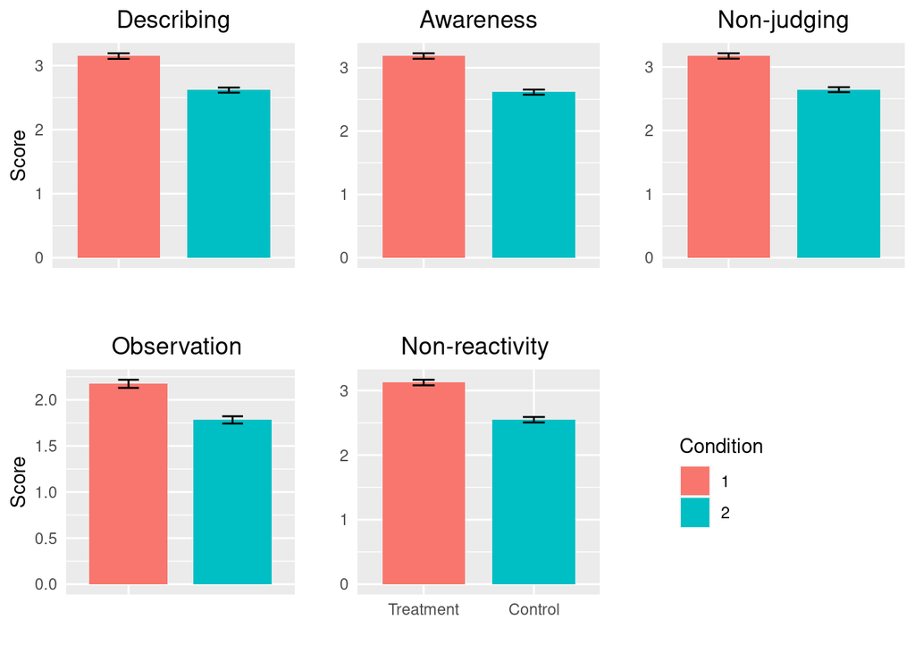

```r
grid.arrange(plt1, plt2, plt3, plt4, plt5, nrow = 2)
```

The treatment group had significantly higher mean scores for all five factors associated with the FFMQ - this is evidence that the mindfulness app is effective in improving all five identified factors.

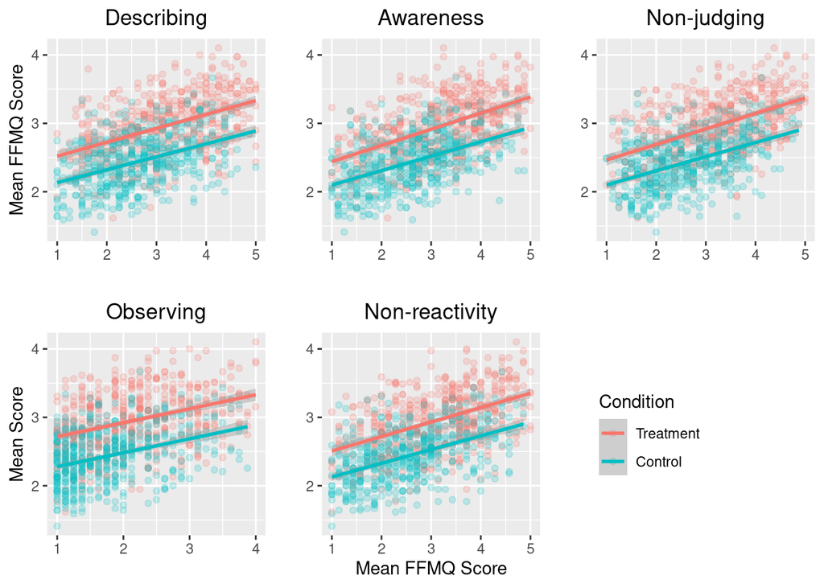

```r
# factor x ffmq
plt1 <- ggplot(data=df, mapping=aes(x=fa1_mean,y=ffmq_mean, color=as.factor(group)))+
  geom_point(alpha=0.2)+ # plot each individual point
  geom_smooth(method=lm, se=TRUE, fullrange=FALSE, level=0.95)+ # and a regression line 95ci se
  labs(y='Mean FFMQ Score', x=' ')+ # update labels
  ggtitle('Describing')+
  theme(legend.position = "none",plot.title = element_text(hjust = 0.5)) # no need for legend (x-labels suffice)

plt2 <- ggplot(data=df, mapping=aes(x=fa2_mean,y=ffmq_mean, color=as.factor(group)))+
  geom_point(alpha=0.2)+
  geom_smooth(method=lm, se=TRUE, fullrange=FALSE, level=0.95)+
  labs(y='', x=' ')+
  ggtitle('Awareness')+
  theme(legend.position = "none",plot.title = element_text(hjust = 0.5))

plt3 <- ggplot(data=df, mapping=aes(x=fa3_mean,y=ffmq_mean, color=as.factor(group)))+
  geom_point(alpha=0.2)+
  geom_smooth(method=lm, se=TRUE, fullrange=FALSE, level=0.95)+
  labs(y='', x='')+
  ggtitle('Non-judging')+
  theme(legend.position = "none",plot.title = element_text(hjust = 0.5))

plt4 <- ggplot(data=df, mapping=aes(x=fa4_mean,y=ffmq_mean, color=as.factor(group)))+
  geom_point(alpha=0.2)+
  geom_smooth(method=lm, se=TRUE, fullrange=FALSE, level=0.95)+
  labs(y='Mean Score', x='')+
  ggtitle('Observing')+
  theme(legend.position = "none",plot.title = element_text(hjust = 0.5))

plt5 <- ggplot(data=df, mapping=aes(x=fa5_mean,y=ffmq_mean, color=as.factor(group)))+
  geom_point(alpha=0.2)+
  geom_smooth(method=lm, se=TRUE, fullrange=FALSE, level=0.95)+
  labs(color='Condition', y='', x='Mean FFMQ Score')+
  ggtitle('Non-reactivity')+
  theme(legend.position = c(1.5, 0.5),plot.title = element_text(hjust = 0.5))+
  scale_color_discrete(labels=c('Treatment','Control'))

grid.arrange(plt1, plt2, plt3, plt4, plt5, nrow = 2)
```

```r
# significance testing
ffmq.fa1_lm <- lm(ffmq_mean~fa1_mean+fa2_mean+fa3_mean+fa4_mean+fa5_mean, data=df)
summary(ffmq.fa1_lm)
```

```
##
## Call:
## lm(formula = ffmq_mean ~ fa1_mean + fa2_mean + fa3_mean + fa4_mean +
##     fa5_mean, data = df)
##
## Residuals:
##        Min         1Q     Median         3Q        Max
## -5.881e-14 -9.300e-17  5.300e-17  2.050e-16  1.070e-14
##
## Coefficients:
##               Estimate Std. Error    t value Pr(>|t|)
## (Intercept) -1.123e-15  3.433e-16 -3.273e+00   0.0011 **
## fa1_mean     2.051e-01  6.315e-17  3.248e+15   <2e-16 ***
## fa2_mean     2.051e-01  6.357e-17  3.227e+15   <2e-16 ***
## fa3_mean     2.051e-01  6.511e-17  3.150e+15   <2e-16 ***
## fa4_mean     2.051e-01  8.144e-17  2.519e+15   <2e-16 ***
## fa5_mean     1.795e-01  6.233e-17  2.880e+15   <2e-16 ***
## ---
## Signif. codes:  0 '***' 0.001 '**' 0.01 '*' 0.05 '.' 0.1 ' ' 1
##
## Residual standard error: 1.919e-15 on 994 degrees of freedom
## Multiple R-squared:      1,  Adjusted R-squared:      1
## F-statistic: 1.281e+31 on 5 and 994 DF,  p-value: < 2.2e-16
```

From this we see that the factors are largely equal in their association with overall FFMQ scores in that they all show a significant association - this implies that if an individual is high in one score, they are likely to be high in the other factors as well.

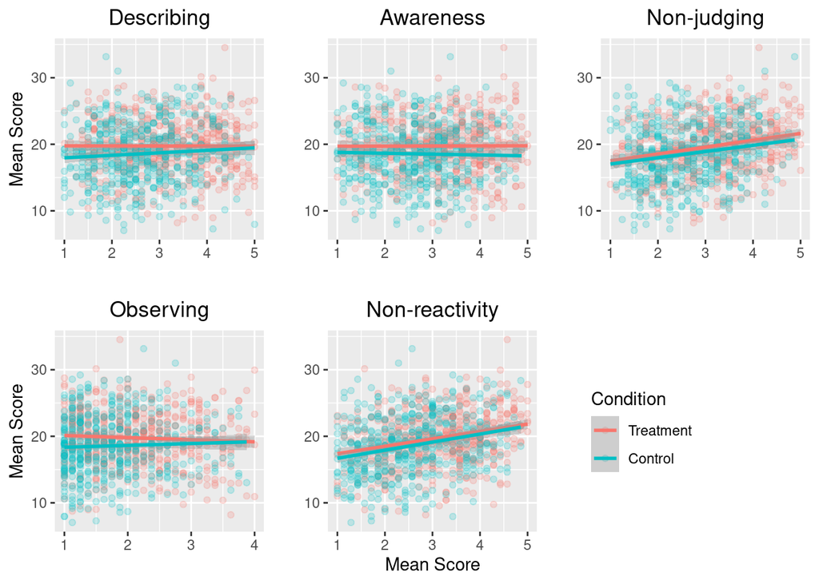

```r
# factor x ic_scoops
plt1 <- ggplot(data=df, mapping=aes(x=fa1_mean,y=ic_scoops, color=as.factor(group)))+
  geom_point(alpha=0.2)+ # plot each individual point
  geom_smooth(method=lm, se=TRUE, fullrange=FALSE, level=0.95)+ # and a regression line 95ci se
  labs(y='Mean Score', x=' ')+ # update labels
  ggtitle('Describing')+
  theme(legend.position = "none",plot.title = element_text(hjust = 0.5)) # no need for legend (x-labels suffice)

plt2 <- ggplot(data=df, mapping=aes(x=fa2_mean,y=ic_scoops, color=as.factor(group)))+
  geom_point(alpha=0.2)+
  geom_smooth(method=lm, se=TRUE, fullrange=FALSE, level=0.95)+
  labs(y='', x=' ')+
  ggtitle('Awareness')+
  theme(legend.position = "none",plot.title = element_text(hjust = 0.5))

plt3 <- ggplot(data=df, mapping=aes(x=fa3_mean,y=ic_scoops, color=as.factor(group)))+
  geom_point(alpha=0.2)+
  geom_smooth(method=lm, se=TRUE, fullrange=FALSE, level=0.95)+
  labs(y='', x='')+
  ggtitle('Non-judging')+
  theme(legend.position = "none",plot.title = element_text(hjust = 0.5))

plt4 <- ggplot(data=df, mapping=aes(x=fa4_mean,y=ic_scoops, color=as.factor(group)))+
  geom_point(alpha=0.2)+
  geom_smooth(method=lm, se=TRUE, fullrange=FALSE, level=0.95)+
  labs(y='Mean Score', x='')+
  ggtitle('Observing')+
  theme(legend.position = "none",plot.title = element_text(hjust = 0.5))

plt5 <- ggplot(data=df, mapping=aes(x=fa5_mean,y=ic_scoops, color=as.factor(group)))+
  geom_point(alpha=0.2)+
  geom_smooth(method=lm, se=TRUE, fullrange=FALSE, level=0.95)+
  labs(color='Condition', y='', x='Mean Score')+
  ggtitle('Non-reactivity')+
  theme(legend.position = c(1.5, 0.5),plot.title = element_text(hjust = 0.5))+
  scale_color_discrete(labels=c('Treatment','Control'))

grid.arrange(plt1, plt2, plt3, plt4, plt5, nrow = 2)
```

```r
# significance testing
ffmq.fa1_lm <- lm(ic_scoops~fa1_mean+fa2_mean+fa3_mean+fa4_mean+fa5_mean, data=df)
summary(ffmq.fa1_lm)
```

```
##
## Call:
## lm(formula = ic_scoops ~ fa1_mean + fa2_mean + fa3_mean + fa4_mean +
##     fa5_mean, data = df)
##
## Residuals:
##      Min       1Q   Median       3Q      Max
## -11.1536  -2.6783  -0.1011   2.7728  12.8215
##
## Coefficients:
##             Estimate Std. Error t value Pr(>|t|)
## (Intercept) 13.26007    0.72622  18.259  < 2e-16 ***
## fa1_mean     0.20992    0.13359   1.571    0.116
## fa2_mean    -0.05526    0.13449  -0.411    0.681
## fa3_mean     0.87453    0.13775   6.349  3.3e-10 ***
## fa4_mean    -0.06441    0.17230  -0.374    0.709
## fa5_mean     1.07166    0.13187   8.127  1.3e-15 ***
## ---
## Signif. codes:  0 '***' 0.001 '**' 0.01 '*' 0.05 '.' 0.1 ' ' 1
##
## Residual standard error: 4.06 on 994 degrees of freedom
## Multiple R-squared:  0.1197, Adjusted R-squared:  0.1153
## F-statistic: 27.04 on 5 and 994 DF,  p-value: < 2.2e-16
```

From this we see that the most factors that drive the relationship between FFMQ scores and task score are factor5 (t(994)=8.127, p < 0.001) followed by factor3 (t(994)=6.349, p < 0.001), with the other factors showing non-significant effects.